# Tutorial 7: Comparing Two Means

### Means Plots

When you are analysing and presenting data comparing two means, it is typical (and sensible!) to visualise this relationship by presenting plots of the means. We’ll go through the steps of creating a means plot with error bars below.

### Task 9

We’ll start by looking at one of the main hypotheses of the original study: namely, that people in different conditions would have different mean ratings of how much they like Pepper.

#### Task 9.1

Use `ggplot()` to map the variables that we will use, add nice labels, and choose a theme. Save this as `like.plot` and call it to have a look.

**Solution**

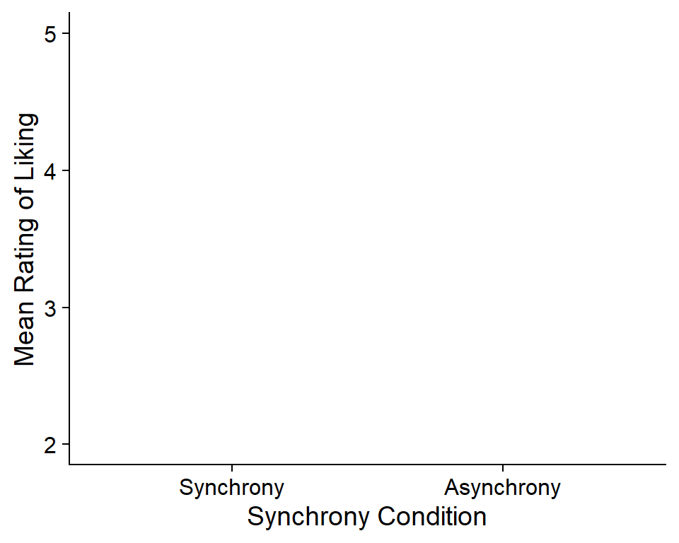

```r
like.plot <- sync %>%
  ggplot(aes(x = condition, y = liking)) +
  labs(x = "Synchrony Condition", y = "Mean Rating of Liking") +
  theme_cowplot()

like.plot
```

So, now we have a nice blank canvas on which we can draw our plot. One of the ways to make the plot-building process easier is to set up and save the elements of the plot you are sure of, as we’ve just done. Then, we can just add more layers to the plot using `+`.

#### Task 9.2

Add a geom to your plot to draw points on it, jittered a bit.

**Solution**

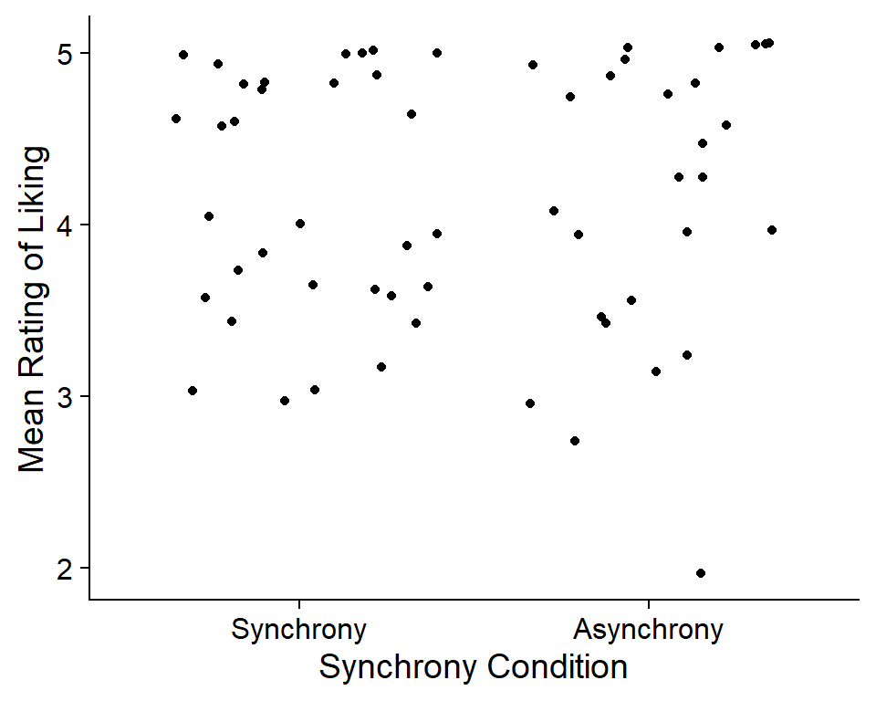

```r
like.plot +
  geom_point(position = "jitter")
```

We now have a scatterplot that gives us an idea of how our data are distributed in each condition. This isn’t quite what we want, though - we don’t want to plot the data itself, but rather the mean in each condition. To do this, we need to tell R that we want a summary of the data, rather than the data itself; and that the summary we want is the mean.

#### Task 9.3

Add the following code to your plot to create means in each condition.

```r
geom_point(stat = "summary",
           fun.y = "mean")
```

**Solution**

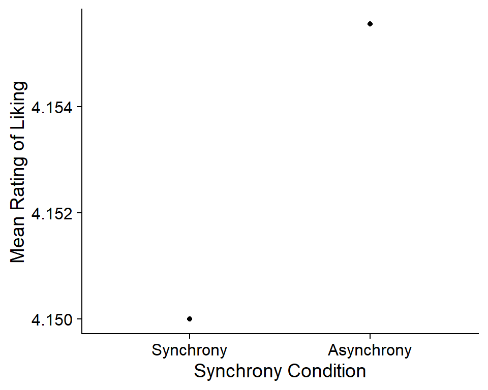

```r
like.plot +
  geom_point(stat = "summary",
           fun.y = "mean")
```

Huh. That’s what we wanted, but it looks like the difference in means is enormous. Based on the scatterplot we saw above, it didn’t look like there would be a big difference. If we take a look at the *y*-axis, we can see why: R has changed the scale to make the difference between the points look huge. R is just trying to be helpful, but this misrepresents the actual size of the difference and makes the plot very difficult to interpret. Let’s override that automatic adjustment and choose our own scale. Since the ratings of `liking` ranged from 0 to 5, let’s set our *y*-axis to the same values.

#### Task 9.4

Add the following code to change the limits on the *y*-axis by replacing `...` with numbers.

```r
ylim(...)
```

**Solution**

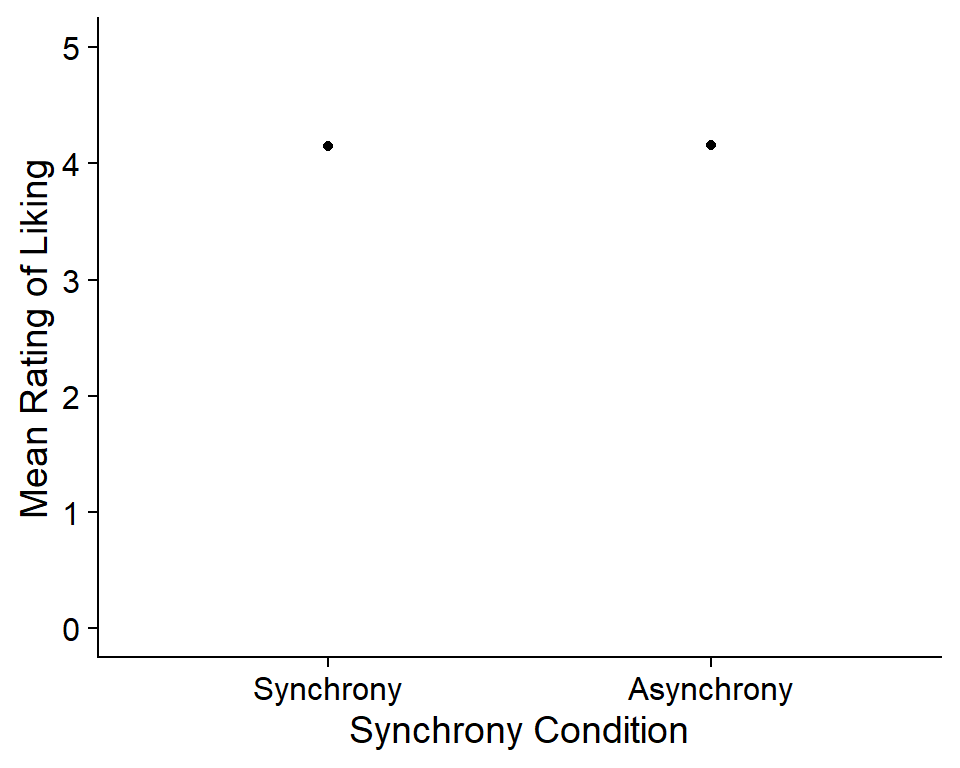

```r
like.plot +
  geom_point(stat = "summary",
           fun.y = "mean") +
  ylim(0, 5)
```

That’s more like it. Those single black dots are pretty boring, though - let’s pick something more interesting.

#### Task 9.5

Add the following arguments to `geom_point()` to change the size and shape of the points. Each argument should be completed with a number.

**Hint:** if you choose a number for `shape =` between 21 and 25, you can also add an extra argument, `fill =`, which you can complete with a colour. Some helpful websites:

- [Shape options](http://sape.inf.usi.ch/quick-reference/ggplot2/shape)
- [Shapes and colours](http://www.sthda.com/english/wiki/ggplot2-point-shapes)

```r
size = ...
shape = ...
```

**Solution**

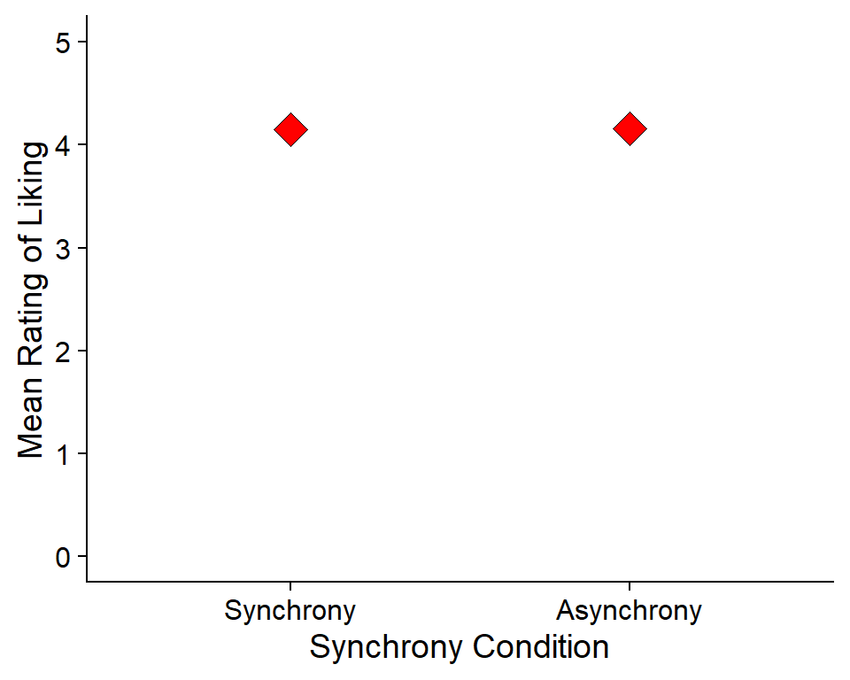

```r
like.plot +
  geom_point(stat = "summary",
           fun.y = "mean",
           size = 5, # chosen at random - larger numbers make bigger points
           shape = 23,
           fill = "red") +
  ylim(0, 5)
```

Now that’s looking a bit better. The last thing we want here is some measure of the variance around the mean. Since we’ve talked about them a lot, and we’ll see them in our output later, let’s put some error bars around our means that represent 95% confidence intervals.

#### Task 9.6

Add the following code to your plot to create error bars.

```r
stat_summary(fun.data="mean_cl_boot",geom="errorbar")
```

**Solution**

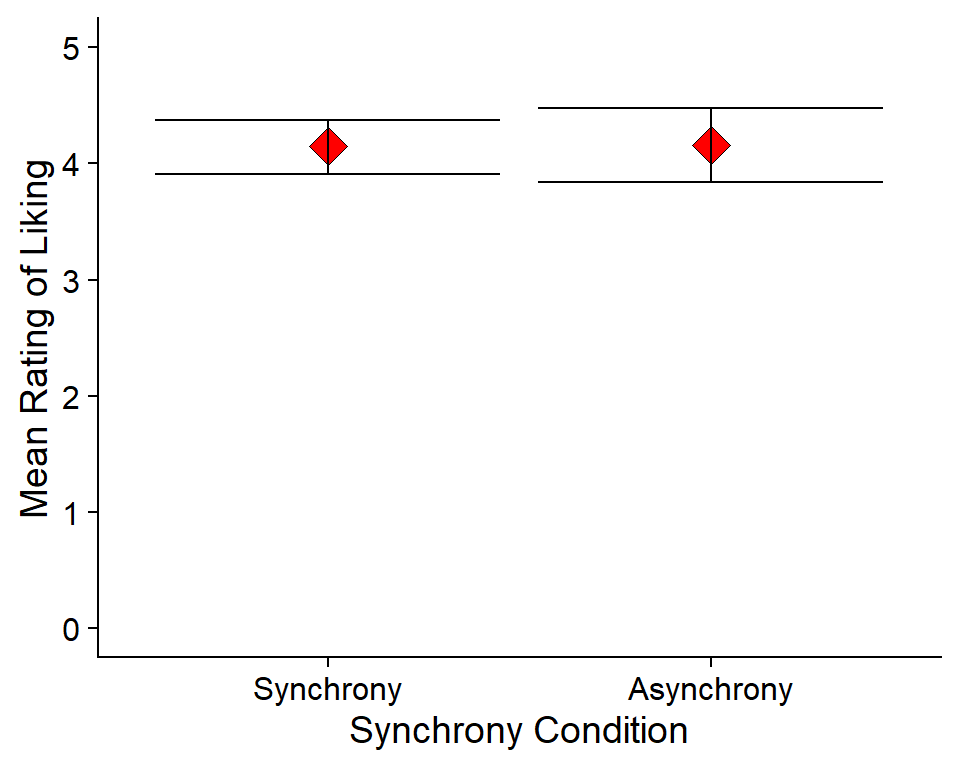

```r
like.plot +
  geom_point(stat = "summary",
           fun.y = "mean",
           size = 5, # chosen at random - larger numbers make bigger points
           shape = 23,
           fill = "red") +
  ylim(0, 5) +
  stat_summary(fun.data="mean_cl_boot",geom="errorbar")
```

We’re almost there! One, I think those error bars are a little Extra (tm), so let’s make them a little less [Lady Gaga](https://www.google.com/search?q=lady+gaga+shoulder+pads) using `width =` in the `stat_summary()` function. We can also get rearrange the order of the layers so the points are drawn on top of (i.e. after) the error bars, instead of underneath.

#### Task 9.7

Create the finished plot and save it as `like.plot.final`. Then, call it to have a look.

**Solution**

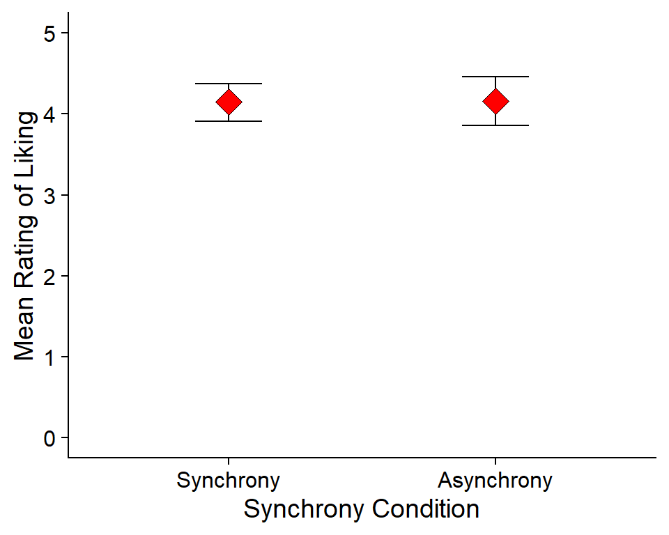

```r
like.plot.final <- like.plot +
  stat_summary(fun.data="mean_cl_boot",geom="errorbar", width = .25) +
  geom_point(stat = "summary",
           fun.y = "mean",
           size = 5, # chosen at random - larger numbers make bigger points
           shape = 23,
           fill = "red") +
  ylim(0, 5)
like.plot.final
```

Finally, we can interpret this plot. We can see that the means of liking in the two synchrony conditions are almost identical, although the confidence intervals are slightly different. This tells us that synchrony condition seemed to make little difference to how much participants liked Pepper, although we’ll need to investigate this with a test to be sure.

### Task 10

Make a similar plot with the following specifications:

- `Gender` on the *x*-axis and `nars1` on the *y*-axis
- Correct labels and scales on both axes
- Plot means as teal circles
- Save as `nars.plot.final`

**Solution**

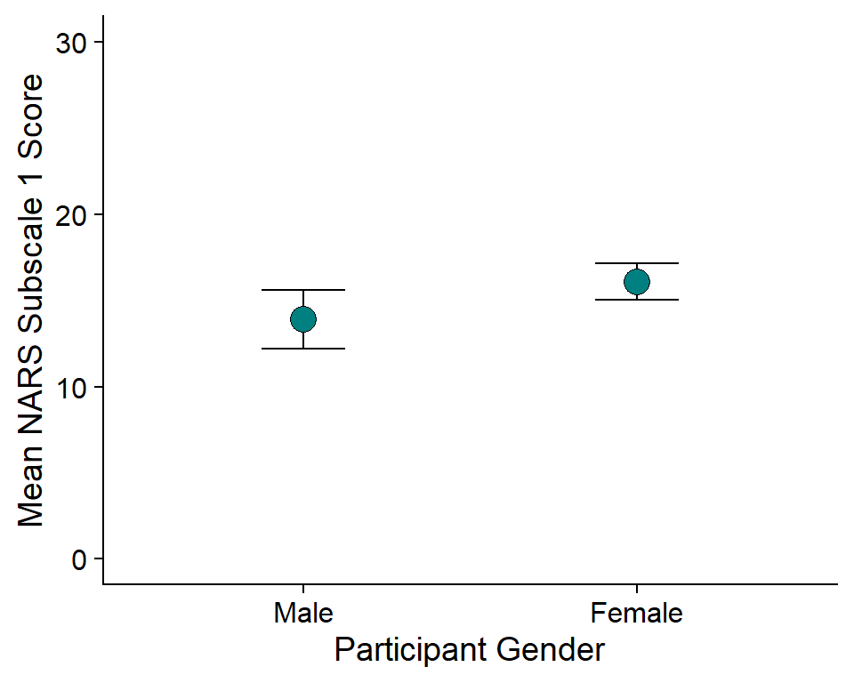

```r
nars.plot.final <- sync %>%
  ggplot(aes(x = Gender, y = nars1)) +
  labs(x = "Participant Gender", y = "Mean NARS Subscale 1 Score") +
  stat_summary(fun.data="mean_cl_boot",geom="errorbar",width = .25) +
  geom_point(stat = "summary",
           fun.y = "mean",
           size = 5, # chosen at random - larger numbers make bigger points
           shape = 21,
           fill = "#008080") + # or whatever colour you chose!
  ylim(0, 30) + # Don't forget to change this!
  theme_cowplot()

nars.plot.final
```

## Comparing Means with `t.test()`

Now that we have some idea of what’s happening in our data, let’s quantify these relationships with an analysis!

Just like we saw last week with `cor.test()`, `t.test()` produces (relatively) clear output and also lets us report our results easily using subsetting, since it produces an `htest` object just like the ones we used for reporting before. So, we can use all the same ideas to run and report our *t*-test.

### Task 11

Open the help documentation for `t.test` and have a look under “Usage” and “Arguments” at how to use it.

We can use the following arguments for `t.test`:

- `x` and (optionally) `y` are vectors of numeric data - i.e., the two variables we want to compare the means of. However, instead we’ll be using…
- `formula` is a (more) mathematical representation of the test you want to run - see below for how to use it!
- `alternative` must be set to one of the three options `"two.sided"`, `"less"`, or `"greater"`. This determines the type of alternative hypothesis. Because we are going to be using two-tailed tests, we will stick with `"two-sided"`.
- `paired` is set to `FALSE` by default. This is fine for the design we have, but if we had repeated measures, we would have to change this to `TRUE.`
- `var.equal` is set to `FALSE` by default. To get our “standard” *t*-test, we have to change this to `TRUE`. See the optional aside, after the analysis tasks, about what this argument means.
- `...` are other options you can change; we’ll stick with the defaults for now.

### Using `formula`

The `formula` argument for `t.test()` is a new one, but in this case, it’s very simple. We’re using `formula` instead of `x` and `y` as before because it’s easier, and it will help us with `lm()` below and for the next few weeks of this module (and next year!).

For this *t*-test, we would like to test whether people in different conditions rated Pepper differently. (You may recall from last week that the original study hypothesized that people in the Synchrony condition would like Pepper more than people in the Asynchrony condition.) In other words, we want to know whether `liking` changes depending on `condition`. We can translate this into a formula for R by simply inserting the operator `~`, which you can read as “changes depending on.” So, we can write our formula in this case as `liking ~ condition`.

### Task 12

Using what you’ve learned so far, try running a *t*-test comparing the means of `liking` in the two `condition` groups and save the output as `like.t`.

**Solution**

```r
like.t <- t.test(liking ~ condition, data = sync, alternative = "two.sided", var.equal = T)

# We can also use a pipe to do this - note the . to tell R where to pipe the dataset
sync %>%
  t.test(liking ~ condition, ., alternative = "two.sided", var.equal = T)

    Two Sample t-test

data:  liking by condition
t = -0.027812, df = 57, p-value = 0.9779
alternative hypothesis: true difference in means is not equal to 0
95 percent confidence interval:
 -0.4055577  0.3944466
sample estimates:
 mean in group Synchrony mean in group Asynchrony
                4.150000                 4.155556
```

When we run this function, the output is some reasonably easy to read information about the results of our test. We can see here that we have:

- The type of analysis we asked for (Two Sample *t*-test) and the variables we used
- The values of *t*, degrees of freedom, and *p*
- The 95% confidence interval around the difference in means
- The means of each group

#### Task 12.1

Stop and look at the values that the output has given you. Based on what you have learned from the lecture, write down what you think this result means, and how you could interpret it.

**Interpretation**

First, we can see that there is extremely little difference between the means - they were almost exactly the same in the two conditions. We also saw this when we made our means plots earlier, so this shouldn’t be a surprise. Accordingly, the value of *t* is very small; this means that the difference in the means is tiny compared to how much we might expect the differences between means to vary. In other words, there isn’t much signal compared to the amount of noise!

As we saw in the lecture, to quantify this, we find the probability of obtaining this value for *t* if the true difference between the means is 0 - that is, if `condition` has no effect on `liking`, and these means of `liking` actually come from the same population. We do this using a *t*-distribution with the degrees of freedom given in the output - namely, 57. As we can see, it is extremely likely - almost certain, in fact! - that we would find a value of *t* this big (or bigger) if there was no real difference in the means, because *p* = .978. We can conclude from this that we should retain the null hypothesis, that synchrony condition makes no difference to how much people liked Pepper.

Finally, we can also have a look at the confidence intervals. These are confidence intervals around the difference in means, which is not explicitly stated in the output. However, we can calculate it by simply finding the difference between the two means, which is 4.15 - 4.16 = -0.01. That’s pretty tiny on our rating scale of 0 - 5! The confidence intervales give us a range of values that, for 95% of intervals, will contain the true population value. Because we are looking at the **difference** in means, we should check whether these confidence intervals cross or include 0. This is because a difference of 0 means that the means are exactly the same (which you might recognise as our null hypothesis). We can already see that the difference is means that we just calculated is barely different from 0 anyway; but we can also see that the lower CI is negative, and the higher CI is positive. This means that 0 lies within the confidence interval, so the true difference in means in the population could in fact be 0.

#### Task 12.2

Using what you learned about subsetting `htest` objects last week, copy the following paragraph into your Markdown document and report the results of this analysis as demonstrated in the lecture by filling it in with inline code. If you prefer, you are welcome to write the results in your own words instead.

**Hint**: if you can’t remember what the elements are called to use in your reporting, try using `str()`, or look under “Values” in the help documentation.

> We investigated whether, as predicted, people would rate their liking of Pepper differently depending on synchrony condition using an independent-measures *t*-test. This test showed that the means in the two conditions were almost identical (*M*<sub>diff</sub> = [code], 95% CI [ [code], [code]]) and there was no significant difference between the two groups on ratings of liking (*t* ([code]) = [code], *p* = [code]).

**Solution**

[output not shown]

This should appear in Markdown as:

We investigated whether, as predicted, people would rate their liking of Pepper differently depending on synchrony condition using an independent-measures *t*-test. This test showed that the means in the two conditions were almost identical (*M*<sub>diff</sub> = -0.01, 95% CI [-0.41, 0.39]) and there was no significant difference between the two groups on ratings of liking (*t* (57) = -0.03, *p* = .978).

**Note:** I’m using `rd()` from the `weights` package instead of `round()` for the *p*-value because it drops the leading 0, which is what I want; `round()` does not do this. For more about reporting *p*-values using inline code, see the [Creating Functions section in last week’s tutorial](http://users.sussex.ac.uk/~jm636/tut_05_cor_chisq.html#bonus:_creating_functions)

### Using `var.equal`

You may have noticed that the only argument in `t.test()` that we have to change from the default is `var.equal`, which we are setting to `TRUE`. This argument specifies whether the variances of the two samples from which we are getting our means are equal. This is an important assumption of the standard *t*-test, but we haven’t talked much about assumptions yet this year. If you’re interested in a brief preview of some of next year’s topics, read on.

Essentially, the *t*-test - or, indeed, any statistical test - only works the way we want it to if its assumptions are met. We ran into the idea of assumptions before with chi-squared, where the expected frequencies had to be bigger than 5 in each cell. You can think of assumptions like the prerequisites on a module. If you don’t meet the prerequisites, the module will keep going without you, but you might not get the marks you want! In the same way, statistical tests have assumptions, and they only work properly - by which I mean, give you a reliable answer - when those assumptions have been met.

At the moment, we’re not going to worry too much about assumptions, since it’s more important for you to understand the idea of the test itself and how to use it. If you’re interested, though, you can set `var.equal` to `FALSE`, or delete the argument from your command (which will default to `FALSE` anyway). If you do this, you’ll get a slightly different output:

```r
sync %>%
  t.test(liking ~ condition, ., alternative = "two.sided", var.equal = F)

    Welch Two Sample t-test

data:  liking by condition
t = -0.027398, df = 50.978, p-value = 0.9782
alternative hypothesis: true difference in means is not equal to 0
95 percent confidence interval:
 -0.4126370  0.4015259
sample estimates:
 mean in group Synchrony mean in group Asynchrony
                4.150000                 4.155556
```

You might notice a few differences. First, the title: we now have a “Welch” *t*-test. You might also notice that the numbers have changed slightly, even though the overall result is the same. What we have done is tell R that we can’t assume equal variances in our two samples. So, R has run a slightly different test that makes a mathematical adjustment for any differences between the two groups. Of course, if we just always used this adjusted test, we would never need to worry about equal variances at all…but that’s a topic for next year!

### Task 13

Now that you’ve had some step-by-step practice, try doing the entire analysis yourself. Find out whether scores on the first of the NARS scales were different between male and female participants. When you do this, you should:

- Run the analysis using `t.test()`
- Look through the results to understand what they mean
- Write up and report the results in your own words using inline code

**Running and Interpreting the Analysis**

To begin, you have to write out your formula. Here, our predictor is `Gender`, and our outcome is `nars1`. Although it seems a little backwards, we must write this as *outcome ~ predictor(s)*, which here would be `nars1 ~ Gender`. Everything else is the same.

**Solution**

```r
# Make sure you save the result in a new object
# You can name the new object anything you like,
# but it's a good idea to call it something informative (not "result")
nars.t <- sync %>%
  t.test(nars1 ~ Gender, ., alternative = "two.sided", var.equal = T)
nars.t

    Two Sample t-test

data:  nars1 by Gender
t = -2.0374, df = 58, p-value = 0.04619
alternative hypothesis: true difference in means is not equal to 0
95 percent confidence interval:
 -4.33656108 -0.03826792
sample estimates:
  mean in group Male mean in group Female
            13.88235             16.06977
```

Here we can see that male participants had a lower total score on the first NARS scale than female participants. We can see that this difference in means was just over two times bigger than the standard error of the differences in means (using our value of *t*). For 58 degrees of freedom, a difference in means this big or bigger is fairly unlikely to happen if the true difference in means is in fact 0. Since *p* = .046, which is less than .05, we conclude that we should reject the null and accept the alternative - namely, that male and female participants differed on the first NARS scale. The confidence intervals give us more evidence of this, because while the upper bound is quite close to 0, they are both below 0. That tells us that if this interval is one of the 95% of intervals that include the true difference in means in the population, then the true difference in means isn’t 0.

**Note:** The negative sign on *t* just tells us which way round the difference in means was calculated: either male - female or female - male. Here, we can see in the output that the means are given in the order male, then female, probably because of the numerical order of the original codes (0,1). That means that the difference in means was calculated as 13.88 - 16.07 = -2.19, so *t* is also negative.

**Write-up and Reporting**

The following is an **example** of how you could write up these results. You should start practicing writing in your own words, since you will need to do this for your report.

[output not shown]

This will be rendered in Markdown as:

We next investigated whether male and female participants gave different ratings on the Negative Attitude towards Robots Scale (NARS; Nomura, Kanda, & Suzuki, 2006), beginning with the first subscale, negative attitudes toward situations of interaction with robots. Male participants had an average total score of 13.88/30, whereas female participants had an average total score of 16.07/30. This difference was significant (*M*<sub>diff</sub> = -2.19, 95% CI [-4.34, -0.04], *t* (58) = -2.04, *p* = .046), indicating that - since a higher score on the NARS subscales indicates a more negative attitude - female participants on the whole felt more negatively towards interacting with robots.

## Lab Reports

If you have completed all the tasks above, congratulations! You now know everything you need to know to prepare the data, run, interpret, and report the analysis for your lab report if you are going to write about [the red study (Elliot et al., 2010)](https://canvas.sussex.ac.uk/courses/9242/pages/Lab%20Report%20Information%20and%20Resources#red). For your lab report, you should analyse and report your results exactly as we just practiced, using `t.test()`.

If you are planning to write about [the green study (Griskevicius et al, 2010)](https://canvas.sussex.ac.uk/courses/9242/pages/Lab%20Report%20Information%20and%20Resources#green), then you should review [last week’s tutorial and practical on chi-squared](https://canvas.sussex.ac.uk/courses/9242/pages/week-6) instead.

The second bit of this tutorial will look briefly at how to run the same analysis using `lm()`. This is only a preview of the rest of the module after the lab reports are done, when we will look at the linear model in more depth.

## Comparing Means with `lm()`

As we saw in the lecture, we can capture the same relationship as a *t*-test using a linear model (LM). When we do this, we essentially draw a line connecting the two means. Let’s have a look at how this works using the function for creating linear models, called (very sensibly) `lm()`.

### Task 14

Open the help documentation for `lm()` and have a look under “Usage” and “Details” at how to use it.

You will see that `lm()` has a lot of different arguments. This is in part because `lm()` is so versatile, for so many different types of models, so it needs lots of different options. We can essentially ignore them all at the moment, though we might need more of them later on.

One of the reasons we used the `formula` method in `t.test()` is that `lm()` uses the exact same formula as input. Let’s use the second *t*-test we did above, comparing NARS scale 1 in male vs female participants.

### Task 15

Use `lm()` to analyse the difference between male and female participants in their mean NARS subscale 1 scores, and save the result as `nars.lm`.

**Solution**

```r
# The formula and data are the same; just t.test() has changed to lm()

nars.lm <- sync %>%
  lm(nars1 ~ Gender, .)

# Indentical command, just without a pipe
nars.lm <- lm(nars1 ~ Gender, sync)
```

As before, we can call the name of the object to see what’s in it:

```r
nars.lm

Call:
lm(formula = nars1 ~ Gender, data = sync)

Coefficients:
 (Intercept)  GenderFemale
      13.882         2.187
```

These numbers should look familiar from the *t*-test analysis we ran before. You may notice that the value labeled `(Intercept)` is the same as the mean score for male participants that we saw before, i.e. 13.88. The value under `GenderFemale` tells us how much the estimated mean score changes when we move from the category `Male`, the intercept, to `Female`. This value is the same as the difference in means that we saw before, namely 2.19. Essentially, this model represents the following situation:

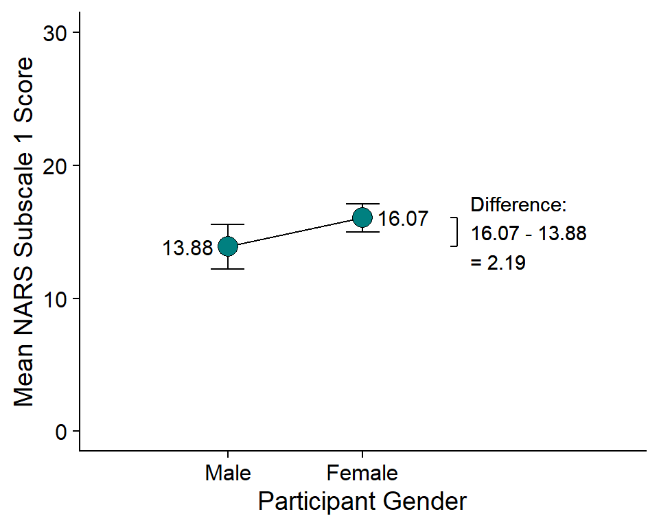

Since I said above that `lm()` is very versatile and has lots of options, it may be surprising that the output we saw above is so simple, with only two numbers in it. If you’re happy with that, that’s fine - we’ll dig a bit deeper in a couple of weeks. However, just like we’ve seen with `htest` objects, there’s more stored in this object than gets printed out when we call it.

### Task 16

**Optional:** If you’re interested, trying piping your saved LM output into `class` to see what type of object it is, and into `str()` and `summary()` to see what’s in it.

**Solution**

```r
nars.lm %>% class()
[1] "lm"

nars.lm %>% str()
List of 13
 $ coefficients : Named num [1:2] 13.88 2.19
  ..- attr(*, "names")= chr [1:2] "(Intercept)" "GenderFemale"
 $ residuals    : Named num [1:60] -6.0698 -5.8824 -3.8824 -0.0698 -1.0698 ...
  ..- attr(*, "names")= chr [1:60] "1" "2" "3" "4" ...
 $ effects      : Named num [1:60] -119.675 7.635 -2.272 0.317 -0.683 ...
  ..- attr(*, "names")= chr [1:60] "(Intercept)" "GenderFemale" "" "" ...
 $ rank         : int 2
 $ fitted.values: Named num [1:60] 16.1 13.9 13.9 16.1 16.1 ...
  ..- attr(*, "names")= chr [1:60] "1" "2" "3" "4" ...
 $ assign       : int [1:2] 0 1
 $ qr           :List of 5
  ..$ qr   : num [1:60, 1:2] -7.746 0.129 0.129 0.129 0.129 ...
  .. ..- attr(*, "dimnames")=List of 2
  .. .. ..$ : chr [1:60] "1" "2" "3" "4" ...
  .. .. ..$ : chr [1:2] "(Intercept)" "GenderFemale"
  .. ..- attr(*, "assign")= int [1:2] 0 1
  .. ..- attr(*, "contrasts")=List of 1
  .. .. ..$ Gender: chr "contr.treatment"
  ..$ qraux: num [1:2] 1.13 1.21
  ..$ pivot: int [1:2] 1 2
  ..$ tol  : num 1e-07
  ..$ rank : int 2
  ..- attr(*, "class")= chr "qr"
 $ df.residual  : int 58
 $ contrasts    :List of 1
  ..$ Gender: chr "contr.treatment"
 $ xlevels      :List of 1
  ..$ Gender: chr [1:2] "Male" "Female"
 $ call         : language lm(formula = nars1 ~ Gender, data = sync)
 $ terms        :Classes 'terms', 'formula'  language nars1 ~ Gender
  .. ..- attr(*, "variables")= language list(nars1, Gender)
  .. ..- attr(*, "factors")= int [1:2, 1] 0 1
  .. .. ..- attr(*, "dimnames")=List of 2
  .. .. .. ..$ : chr [1:2] "nars1" "Gender"
  .. .. .. ..$ : chr "Gender"
  .. ..- attr(*, "term.labels")= chr "Gender"
  .. ..- attr(*, "order")= int 1
  .. ..- attr(*, "intercept")= int 1
  .. ..- attr(*, "response")= int 1
  .. ..- attr(*, ".Environment")=<environment: 0x0000018f9fa41c20>
  .. ..- attr(*, "predvars")= language list(nars1, Gender)
  .. ..- attr(*, "dataClasses")= Named chr [1:2] "numeric" "factor"
  .. .. ..- attr(*, "names")= chr [1:2] "nars1" "Gender"
 $ model        :'data.frame':  60 obs. of  2 variables:
  ..$ nars1 : num [1:60] 10 8 10 16 15 14 13 17 11 16 ...
  ..$ Gender: Factor w/ 2 levels "Male","Female": 2 1 1 2 2 2 2 2 2 2 ...
  ..- attr(*, "terms")=Classes 'terms', 'formula'  language nars1 ~ Gender
  .. .. ..- attr(*, "variables")= language list(nars1, Gender)
  .. .. ..- attr(*, "factors")= int [1:2, 1] 0 1
  .. .. .. ..- attr(*, "dimnames")=List of 2
  .. .. .. .. ..$ : chr [1:2] "nars1" "Gender"
  .. .. .. .. ..$ : chr "Gender"
  .. .. ..- attr(*, "term.labels")= chr "Gender"
  .. .. ..- attr(*, "order")= int 1
  .. .. ..- attr(*, "intercept")= int 1
  .. .. ..- attr(*, "response")= int 1
  .. .. ..- attr(*, ".Environment")=<environment: 0x0000018f9fa41c20>
  .. .. ..- attr(*, "predvars")= language list(nars1, Gender)
  .. .. ..- attr(*, "dataClasses")= Named chr [1:2] "numeric" "factor"
  .. .. .. ..- attr(*, "names")= chr [1:2] "nars1" "Gender"
 - attr(*, "class")= chr "lm"

nars.lm %>% summary()

Call:
lm(formula = nars1 ~ Gender, data = sync)

Residuals:
    Min      1Q  Median      3Q     Max
-7.0698 -2.3198 -0.0698  2.3208  8.9302

Coefficients:
             Estimate Std. Error t value Pr(>|t|)
(Intercept)   13.8824     0.9089  15.274   <2e-16 ***
GenderFemale   2.1874     1.0737   2.037   0.0462 *
---
Signif. codes:  0 '***' 0.001 '**' 0.01 '*' 0.05 '.' 0.1 ' ' 1

Residual standard error: 3.748 on 58 degrees of freedom
Multiple R-squared:  0.06679,   Adjusted R-squared:  0.0507
F-statistic: 4.151 on 1 and 58 DF,  p-value: 0.04619
```

First, we have a new class of object, `lm`, which is unsurprising; this class of object contains linear models.

As for the rest, it looks like what we saw above was just the tip of the iceberg! We will look at some of these values and options in future weeks. For now, just notice that in the output from `summary()`, we get a *t*-value and *p*-value for `GenderFemale` that should also look familiar from above!

## Recap

You made it! That was, again, a lot of information, but remember that this tutorial is as much a reference for you in the future as it is for you to practice right now. You’re welcome - and encouraged! - to keep working with this data to practice what we’ve learned today. In sum, we’ve covered:

- How to prepare and visualise data for comparing two means
- How to compare means using `t.test()`, read the output, and store the results as an `htest` object
- How to interpret and write up the results and output from `t.test()`
- How to compare means using `lm()`, briefly

That’s all for this week. See you soon!